# Clusterwise Regression

#### Run the Algorithm

I run the auto data through the **clustreg** function. 2 and 3 cluster solutions over 30 iterations both yielded better goodness of fit metrics, rmse, r-squared, and less heteroskedastic residual distributions. The 3 cluster solution shows the following number of records falling into each cluster. These are the same records that were therefore used to fit the final model in the last iteration.

```
clusters
  1   2   3
136  98 158
```

```
Call:
lm(formula = target.vector ~ . - cluster, data = x.data, subset = cluster ==
    i)

Residuals:
    Min      1Q  Median      3Q     Max
-3.8893 -1.0975 -0.0273  0.7959  7.0687

Coefficients:
               Estimate Std. Error t value Pr(>|t|)
(Intercept)  15.1853918  3.6379390   4.174 5.49e-05 ***
cylinders    -0.2841817  0.2915671  -0.975    0.332
displacement  0.0092797  0.0068820   1.348    0.180
horsepower   -0.0898886  0.0118572  -7.581 6.12e-12 ***
weight       -0.0077207  0.0005782 -13.352  < 2e-16 ***
acceleration -0.9696002  0.0825363 -11.748  < 2e-16 ***
year          0.7179777  0.0370569  19.375  < 2e-16 ***
origin       -0.1636332  0.1959393  -0.835    0.405
---
Signif. codes:  0 '***' 0.001 '**' 0.01 '*' 0.05 '.' 0.1 ' ' 1

Residual standard error: 1.569 on 128 degrees of freedom
Multiple R-squared:  0.9464,    Adjusted R-squared:  0.9435
F-statistic: 323.2 on 7 and 128 DF,  p-value: < 2.2e-16
```

The cluster 2 model also yields a R-squared of 0.95 on 90 degrees of freedom. 6 of the 7 predictors show significantly strong nonzero linear relationships with *mpg*. Only 1 variable, cylinders, is an insignificant predictor of mpg in this submodel.

```
Call:
lm(formula = target.vector ~ . - cluster, data = x.data, subset = cluster ==
    i)

Residuals:
    Min      1Q  Median      3Q     Max
-3.5848 -0.7030  0.0508  0.8236  4.4401

Coefficients:
               Estimate Std. Error t value Pr(>|t|)
(Intercept)  -2.553e+01  4.439e+00  -5.752 1.20e-07 ***
cylinders    -1.649e-01  3.685e-01  -0.448   0.6555
displacement  2.241e-02  8.313e-03   2.695   0.0084 **
horsepower   -1.593e-01  1.942e-02  -8.201 1.57e-12 ***
weight       -4.761e-03  7.957e-04  -5.983 4.37e-08 ***
acceleration  8.292e-01  1.008e-01   8.228 1.38e-12 ***
year          8.432e-01  5.215e-02  16.170  < 2e-16 ***
origin       -1.135e+00  2.545e-01  -4.459 2.37e-05 ***
---
Signif. codes:  0 '***' 0.001 '**' 0.01 '*' 0.05 '.' 0.1 ' ' 1

Residual standard error: 1.613 on 90 degrees of freedom
Multiple R-squared:  0.9532,    Adjusted R-squared:  0.9495
F-statistic: 261.6 on 7 and 90 DF,  p-value: < 2.2e-16
```

The cluster 3 model has the highest R-square of 0.96 on 150 degrees of freedom. 5 of the 7 predictors show significant nonzero linear relationships with *mpg*. Displacement and horsepower do not appear to share any linear relationship with the target variable for the subset of cars that were in the 3rd cluster.

```
Call:
lm(formula = target.vector ~ . - cluster, data = x.data, subset = cluster ==
    i)

Residuals:
    Min      1Q  Median      3Q     Max
-3.8299 -0.7997  0.0282  0.7201  7.6108

Coefficients:
               Estimate Std. Error t value Pr(>|t|)
(Intercept)  -1.223e+01  3.785e+00  -3.230 0.001523 **
cylinders    -7.512e-01  2.129e-01  -3.527 0.000557 ***
displacement  2.622e-03  5.177e-03   0.506 0.613306
horsepower   -5.378e-03  8.776e-03  -0.613 0.540941
weight       -2.597e-03  4.827e-04  -5.381  2.8e-07 ***
acceleration -1.758e-01  7.814e-02  -2.249 0.025955 *
year          5.329e-01  4.209e-02  12.661  < 2e-16 ***
origin        6.778e+00  2.863e-01  23.675  < 2e-16 ***
---
Signif. codes:  0 '***' 0.001 '**' 0.01 '*' 0.05 '.' 0.1 ' ' 1

Residual standard error: 1.502 on 150 degrees of freedom
Multiple R-squared:  0.9601,    Adjusted R-squared:  0.9582
F-statistic: 515.2 on 7 and 150 DF,  p-value: < 2.2e-16
```

Reviewing the interquartile range (IQR) of the residual distributions for each of the 3 subset models when compared to the original fully fit model illustrates the variance reduction obtained by modeling these data as different populations, yielding better model fits as the IQR (middle 50% range of residuals) are clear and substantially smaller than the single full model.

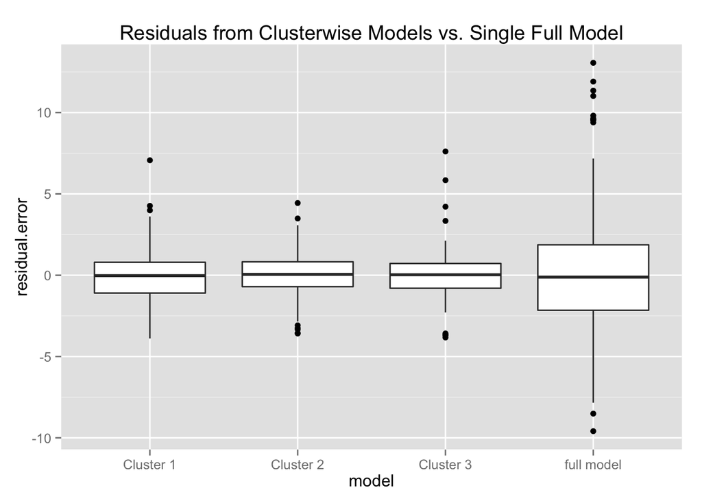

```
    Full Model  Model 1 Model2   Model3
IQR   4.025483 1.893437 1.5266 1.519854
```

Additionally, residual plots of the single full model versus each of the 3 specific cluster models shows that the use of subset models removed almost all visual indication of heteroskedasticity in the residual error distributions. The full model meanwhile, while having a very large percentage of variance explained by the model, shows some heteroskedastic fanning of the residual errors in the higher range of *mpg*. Using clusterwise regression appears to have helped reduce a lot of the pattern in the residual distributions from the full model.

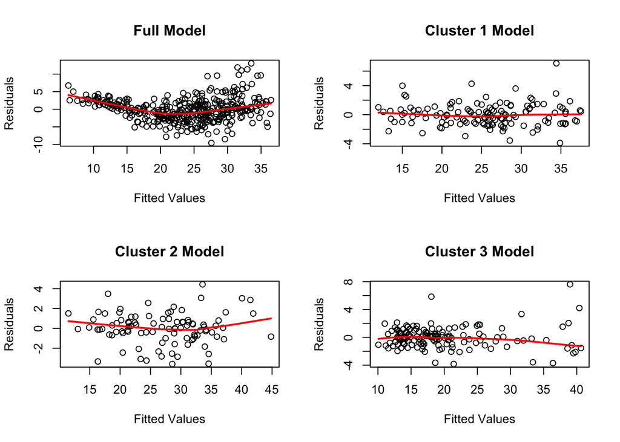

#### Visualize Clusters

Using the final clusters stored in the *clustreg* output list, I visualized the final assigned clusters after applying dimension reduction to the *auto* dataset. I ran a principal components analysis on all 7 predictors of *mpg*. The first 3 principals components accounted for 90% of the variation in the entire predictor dataset, so PC1-3 are adequate representations of the data space. Using a 3D scatterplot, I overlayed the final clusters created from the regression algorithm as a color parameter. It is clear here that we see at least 1 distinct cluster in green, but the other 2 clusters are not confirmed upon visual inspection of the first 3 principal components. This might indicate that on these data, clusterwise regression with k = 3 may not perfectly identify natural clusters of cars. Considering that the full model already does a very good job of explaining the variability in *mpg*, perhaps 3 distinct subset populations of cars is a stretch of a theory.

```
[1] 392   7
```

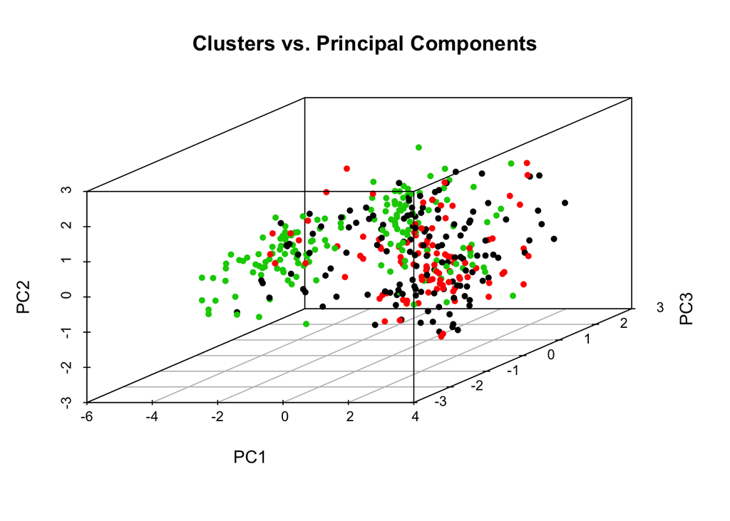

#### Conclusion

Overall, clusterwise regression, which creates k clusters and k submodels as a biproduct of an iterative OLS regression approach shows the potential power of the method in the right environment on the right dataset where multiple populations may be present. I do not think this method is necessarily a go to for any regression problem, but can be used as a diagnostic tool and alternative approach worth exploring when standard OLS regression, regularization methods, and nonlinear methods like natural splines and GAMs may fail to work on the dataset. It should be noted that this analysis is illustrative only and the dataset was chosen because of its simple, clean, and academic nature. No cross-validation was applied to measure the potential bias and prediction variance of these models on unseen data, which should be considered when applying *clustreg* to a prediction problem. If *clustreg* were to be applied to unseen data, the derived clusters would need to be predicted ahead of time! Therefore, modeling the clusters arrived at using a general linear model or other classification method is suggested to be applicable for prediction.